# Exploration of the Exponential Distribution

Sharon Francisco

July 20, 2016

## Synopsis

This report investigates the exponential distribution in R and compares it to the Central Limit Theorem.

## Installing Packages and Loading Libraries

The packages used in the analysis are installed below.

```r
if(!require(ggplot2, quietly = TRUE)) install.packages("ggplot2")
library(ggplot2)
```

## Set Root Directory

```r
rootDir <- "C:/Users/b1050549/Documents/stat_inference"

knitr::opts_knit$set(root.dir = rootDir)
rm(list = ls())
```

## Simulations

To explore the exponential distribution the assignment says to use lamda = 0.2 as the rate parameter.

The mean, mu, of an exponential distribution is 1/lamda, and the standard deviation is also 1/lamda.

```r
lamda <- 0.2
mu <- 1 / lamda
mu
```

```
## [1] 5
```

```r
sigma <- 1 / lamda
popnVar <- sigma^2
popnVar
```

```
## [1] 25
```

So for an exponential distribution with lamda = 0.2, the mean is 5.

Here is a histogram of 1000 simulations of an exponential distribution where lamda = 0.2.

First, I’ll set the seed so the simulation is reproducible.

The **rexp** function takes as arguments the sample size, n, and the rate, which is lamda.

I’ll calculate the mean of the simulated sample and plot a histogram of the simulated sample.

```r
set.seed(7)
n <- 1000
xpSimulation <- rexp(n, rate = lamda)
head(xpSimulation, 50)
```

```
##  [1]  0.24173050  8.11003811  8.56569119  4.06096938  2.72811946
##  [6] 13.10133104  3.75928620 21.36535937  1.02316577  0.22751080
## [11]  4.72109770  3.74013451  9.36004226  9.33720067  6.05167083
## [16]  1.72620034  3.38463872  4.78944968  2.59701231  4.57315953
## [21] 12.00273513  3.16289079  1.98610540  2.20079497  2.74058624
## [26]  1.27760801  2.22989341  6.20236148  8.44310292  9.42060314
## [31]  6.29072539  3.94376010  9.60818173  0.04391806  2.63840357
## [36]  1.93668871  0.44054188  1.59087226  4.63390932  4.46045455
## [41]  3.40742326  1.20837048  7.31353657  0.67722430  4.98364305
## [46]  3.04478956  7.20509768 12.98405171  2.62142731  5.42361642
```

```r
mean(xpSimulation)
```

```
## [1] 5.107448
```

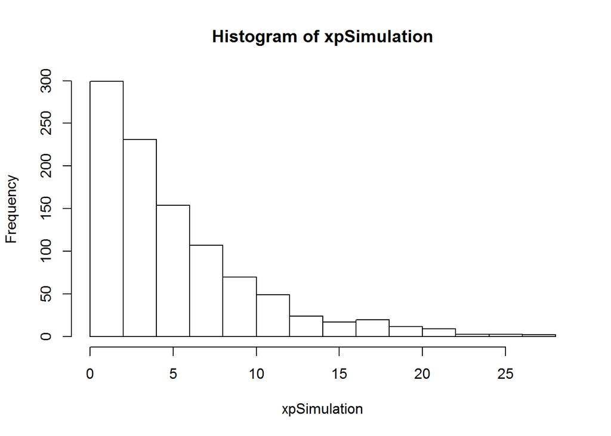

```r
hist(xpSimulation)
```

5.1074476 is the sample mean of the exponential distribution with a sample size, n, of 1000. This is close to the theoretical mean, mu, 5.

Here are the same calculations for sample of 40 exponentials where lamda = 0.2.

```r
set.seed(8)
n <- 40
xpSimulation2 <- rexp(n, rate = lamda)
xpSimulation2
```

```
##  [1]  4.185996634  1.518713178  4.895919482  2.189275040  4.283203641
##  [6]  2.233636072  3.775229621  0.449621156  7.460445650  0.004511423
## [11]  3.996380842  0.211070417  8.345231261  9.230183444 13.217069385
## [16]  1.119326591  0.276186496  3.173656117 10.255391681  1.231490504
## [21]  0.633984284  5.325727747  1.407756583  2.437389991  1.000613812
## [26]  0.913471117  0.087702933  8.991728928  0.362013556 10.767676411
## [31]  7.709911204  5.369893843  0.973286546 19.259912250  3.237181276
## [36]  3.324046005  1.485529759 14.045004507  7.208777191  1.088951121
```

```r
mean(xpSimulation2)
```

```
## [1] 4.442077
```

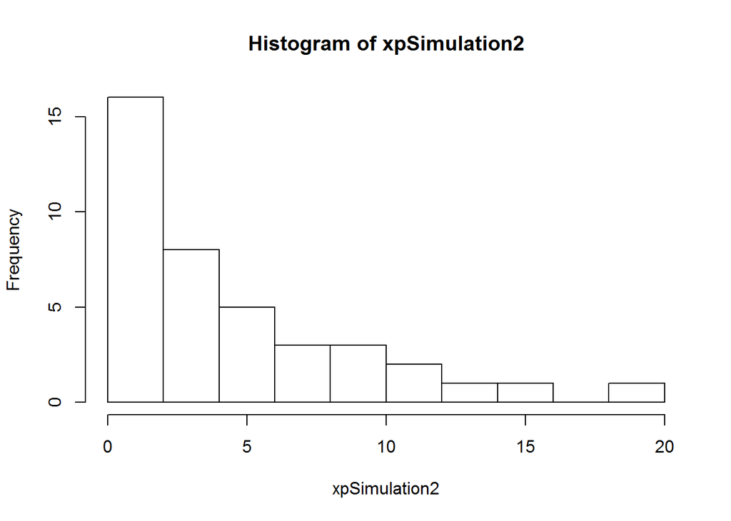

```r
hist(xpSimulation2)
```

4.4420774 is the sample mean of the exponential distribution with n = 40. It is not as close to the theoretical mean, mu = 5, as the simulation with n = 1000, which is not surprising since the sample size, n = 40, is relatively small.

Now I’ll look at the distribution of the averages of 40 exponentials simulated 1000 times.

```r
set.seed(77)
mns = NULL
for(i in 1 : 1000) mns = c(mns, mean(rexp(n, rate = lamda)))
head(mns, 50)
```

```
##  [1] 4.947602 5.688028 6.065135 4.850188 5.355006 4.727920 5.125571
##  [8] 5.462162 3.949619 3.604655 5.022997 4.586781 4.648745 3.751371
## [15] 5.217910 5.316792 4.168643 4.885713 6.312002 5.065052 4.351623
## [22] 4.510892 7.976546 4.335158 5.938997 4.642476 6.645694 4.863157
## [29] 4.366977 4.534632 4.460094 6.649887 4.836563 6.250913 5.280185
## [36] 5.062340 3.615126 4.907996 3.875797 4.353153 4.658380 5.874735
## [43] 6.147725 3.899348 4.981326 5.550440 5.998502 3.990853 5.088673
## [50] 4.774521
```

```r
mean(mns)
```

```
## [1] 4.996833
```

The sample mean, 4.9968333, is very close to the theoretical mean, 5.

Let’s calculate the sample variance.

```r
varnSample <- sigma^2 / n
varnSample
```

```
## [1] 0.625
```

```r
var(mns)
```

```
## [1] 0.6162158
```

Code from course:

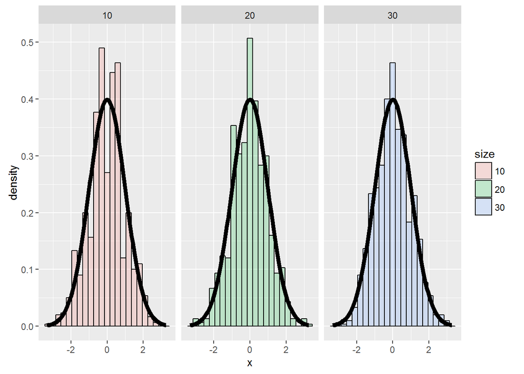

```r
nosim <- 1000
cfunc <- function(x, n) sqrt(n) * (mean(x) - 3.5) / 1.71
dat <- data.frame(
  x = c(apply(matrix(sample(1 : 6, nosim * 10, replace = TRUE),
                     nosim), 1, cfunc, 10),
        apply(matrix(sample(1 : 6, nosim * 20, replace = TRUE),
                     nosim), 1, cfunc, 20),
        apply(matrix(sample(1 : 6, nosim * 30, replace = TRUE),
                     nosim), 1, cfunc, 30)
        ),
  size = factor(rep(c(10, 20, 30), rep(nosim, 3))))
g <- ggplot(dat, aes(x = x, fill = size)) + geom_histogram(alpha = .20, binwidth=.3, colour = "black", aes(y = ..density..))
g <- g + stat_function(fun = dnorm, size = 2)
g + facet_grid(. ~ size)
```

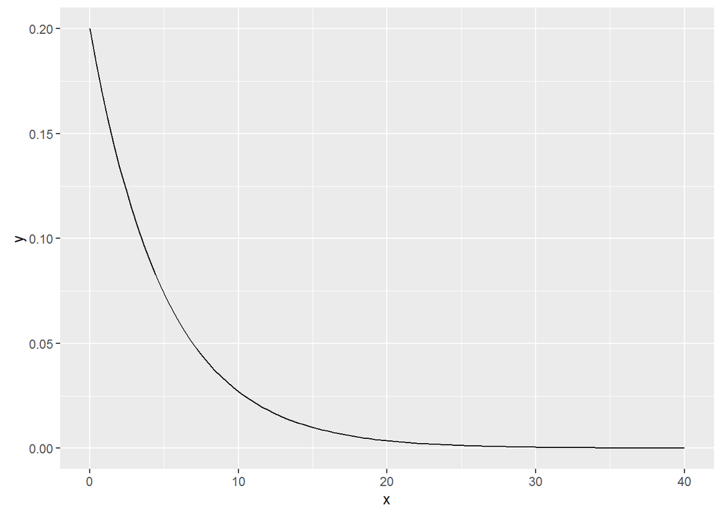

```r
ggplot(data.frame(x = c(0, 40)), aes(x)) +
  stat_function(fun = dexp, geom = "line", args = (mean = lamda))
```

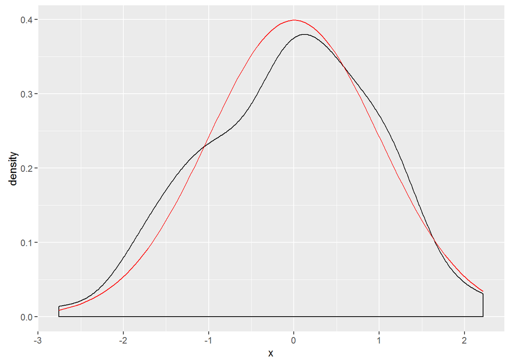

```r
set.seed(1492)
df <- data.frame(x = rnorm(100))
x <- df$x
base <- ggplot(df, aes(x)) + geom_density()
base + stat_function(fun = dnorm, colour = "red")
```

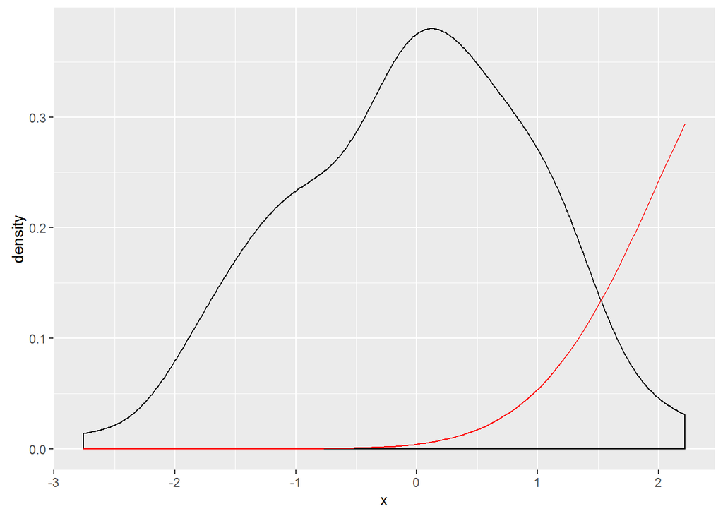

```r
base + stat_function(fun = dnorm, colour = "red", args = list(mean = 3))
```

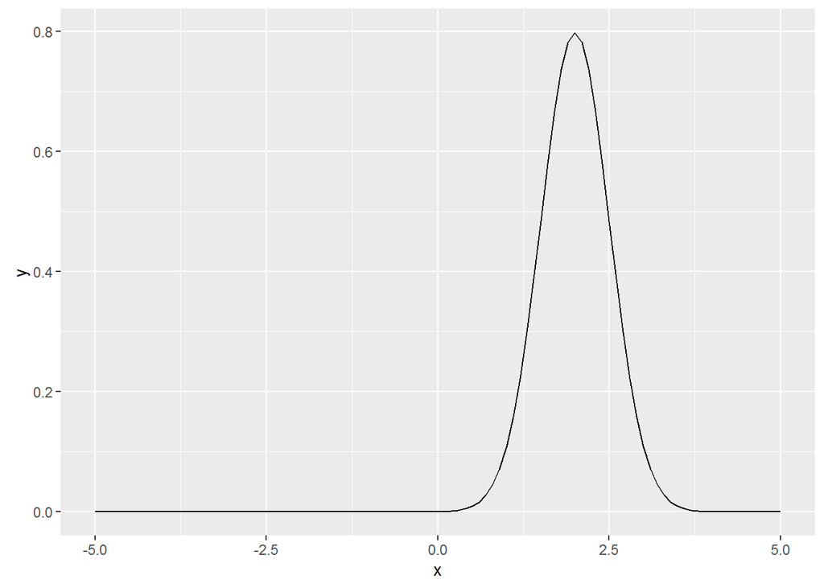

```r
# To specify a different mean or sd, use the args parameter to supply new values
ggplot(data.frame(x = c(-5, 5)), aes(x)) +
  stat_function(fun = dnorm, args = list(mean = 2, sd = .5))
```

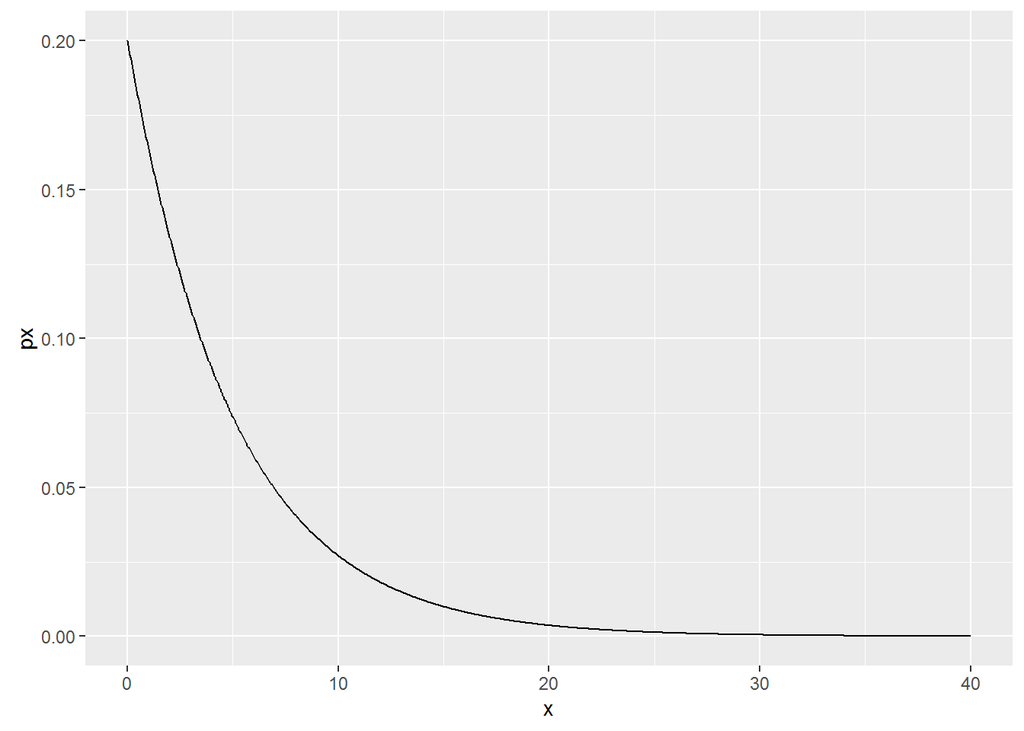

```r
x <- seq(0, 40, length.out=1000)
dat <- data.frame(x=x, px=dexp(x, rate=0.2))
library(ggplot2)
ggplot(dat, aes(x=x, y=px)) + geom_line()
```